# Reanalysis of Nitrogen Depletion RNA-seq in *Chlamydomonas reinhardtii*

Reanalysis of Miller et al. 2010 using DESeq2

Matthew Francoeur

2026-08-03

## Introduction

This document continues the reanalysis of Miller et al.(1), focusing specifically on differential gene expression. Here the count matrices generated by StringTie will be assessed for sample quality and consistency before being passed to DESeq2 for differential expression analysis. Results will be summarized and exported for downstream analysis. For full context on this reanalysis study see the README.

## Data Import and Inspection

In this section, the gene count matrix is imported and its basic attributes inspected

```r
# Load count matrix
count_matrix <- read.csv("~/Desktop/Projects/Chlamydomonas_rnaseq/results/counts/gene_count_matrix.csv",
                   row.names = 1)

# Inspect dimensions
dim(count_matrix)
```

```
## [1] 16661     6
```

The matrix has 16661 rows (genes) and 6 columns (conditions)

```r
# Preview first few rows
head(count_matrix)
```

```
##                 SRR066643 SRR066644 SRR066645 SRR066646 SRR066647 SRR066648
## MSTRG.13|CGL136        21        27        33        13        12        19
## MSTRG.10|AMX2          49        84       231       721       825      1028
## MSTRG.11               27        20        31        25        30        46
## MSTRG.12              105       103       116       120       158       165
## MSTRG.14|CPLD38       423       464       446       242       256       268
## MSTRG.15|CPLD20       400       459       386       493       568       614
```

The first 6 rows of this matrix are shown above. Some genes do not have a known gene name in the annotation, which are identified by their MSTRG ID only.

## Exploratory Analysis

### Coldata Construction

```r
# Make data frame
coldata_df <- data.frame(
  sample = c("SRR066643", "SRR066644", "SRR066645", "SRR066646", "SRR066647", "SRR066648"),
  condition = c("Replete", "Replete", "Replete", "Deprived", "Deprived", "Deprived")
)
row.names(coldata_df) <- coldata_df$sample
coldata_df
```

```
##              sample condition
## SRR066643 SRR066643   Replete
## SRR066644 SRR066644   Replete
## SRR066645 SRR066645   Replete
## SRR066646 SRR066646  Deprived
## SRR066647 SRR066647  Deprived
## SRR066648 SRR066648  Deprived
```

A coldata data frame is defined, mapping each sample to its experimental condition for use by DESeq2

### Build DeSeq2 Object

```r
dds <- DESeqDataSetFromMatrix(
  countData = count_matrix,
  colData = coldata_df,
  design = ~condition
)
```

A DESeq2 object is constructed, the data structure on which DESeq2 is run.

### PCA Plot

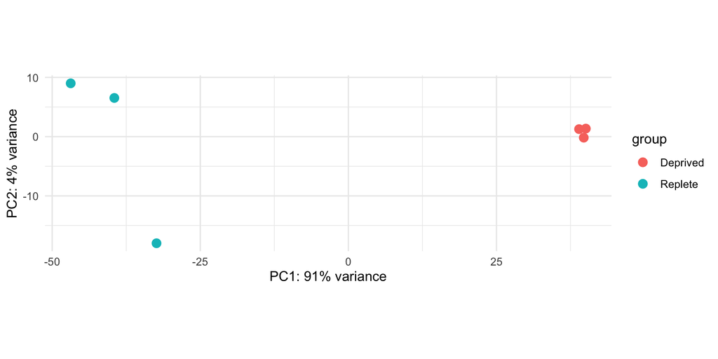

```r
# Apply variance stabilizing transformation
vsd <- vst(dds, blind = TRUE)

# Create PCA plot
plotPCA(vsd, intgroup = "condition") + theme_minimal()
```

A variance stabilizing transformation is applied to the DESeq data set to stabilize gene expression level variation within each sample. A PCA plot is then created from the transformed data and colored by treatment condition. From the resulting plot, it is clear that the samples separate cleanly by treatment group along PC1, which accounts for 91% of the variation in the data set. This indicates that the nitrogen deprivation condition created a robust transcriptional response that will be picked up by DESeq2. PC2 accounts for 4% of the variation in the data set, with the replete condition showing notable separation along this axis. This, as well as greater variation along PC1, indicates potential technical variability among the replete condition, though this does not undermine the analysis given the strong distinction between sample conditions.

### Sample Distance Heatmap

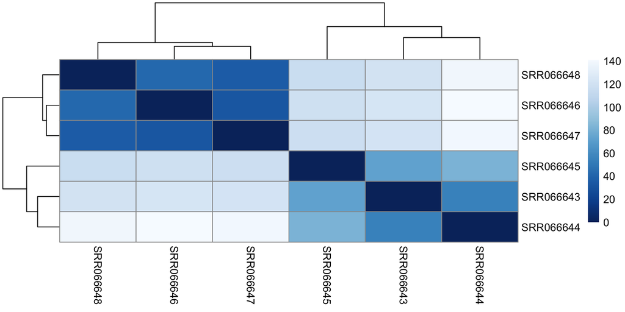

```r
# Calculate distances between each sample
sample_dists <- dist(t(assay(vsd)))

# Plot Heatmap
sample_dist_matrix <- as.matrix(sample_dists)
colors <- colorRampPalette(rev(brewer.pal(9, "Blues")))(255)
pheatmap(
  sample_dist_matrix,
  color = colors,
  clustering_distance_rows = sample_dists,
  clustering_distance_cols = sample_dists
)
```

Heatmap and dendogram analysis further confirm sample clustering by condition. Additionally, the tighter clustering of nitrogen deprivation samples is evident, consistent with the reduced variance observed along PC1 and PC2.

## DESeq2 Analysis

```r
# Set reference condition to replete
dds$condition <- relevel(dds$condition, ref = "Replete")
dds <- DESeq(dds)
res <- results(dds, alpha = 0.05)
summary(res)
```

```
##
## out of 15908 with nonzero total read count
## adjusted p-value < 0.05
## LFC > 0 (up)       : 2332, 15%
## LFC < 0 (down)     : 2626, 17%
## outliers [1]       : 10, 0.063%
## low counts [2]     : 0, 0%
## (mean count < 0)
## [1] see 'cooksCutoff' argument of ?results
## [2] see 'independentFiltering' argument of ?results
```

A summary of DESeq2 results. Using a 5% FDR, 4958 genes were found to be differentially expressed, with 2332 genes upregulated and 2626 genes downregulated. Of note, no low count genes were removed by DESeq2.

```r
# Filter results according to Miller et al.
res_sig <- res[which(res$padj < 0.05 & abs(res$log2FoldChange) >= 1), ]

# Quantify up and down regulated genes
up <- nrow(res_sig[res_sig$log2FoldChange > 0, ])
down <- nrow(res_sig[res_sig$log2FoldChange < 0, ])

# Print
data.frame(
  Direction = c("Upregulated", "Downregulated", "Total"),
  Count = c(
    up,
    down,
    nrow(res_sig)
  )
)
```

```
##       Direction Count
## 1   Upregulated  1535
## 2 Downregulated  1835
## 3         Total  3370
```

Additional filtering was done to match the analysis done by Miller et al (1). In their work, a 5% FDR threshold, as well as a 2-fold expression change between replete and deprived conditions, was used as the criteria for differential expression. After applying these filters, 1535 genes were determined to be upregulated, while 1835 genes were downregulated, leading to 3370 differentially expressed genes. In comparison, Miller et al. (1) found 4003 genes to be differentially expressed, with 2128 upregulated and 1875 downregulated. Thus, both analyses found a similar number of downregulated genes, while this analysis found approximately 600 fewer upregulated genes. Differences in differentially expressed gene counts likely reflect the methodological updates made relative to the original analysis. That being said, it is yet unclear why the differences appear to be concentrated in the upregulated genes.

## Export Results

```r
# Export full results
write.csv(res, "~/Desktop/Projects/Chlamydomonas_rnaseq/results/deseq2/deseq2_results_all.csv", row.names = TRUE)

# Export filtered results
write.csv(res_sig, "~/Desktop/Projects/Chlamydomonas_rnaseq/results/deseq2/deseq2_results_significant.csv", row.names = TRUE)

# Generate and export normalized expression value results
normalized_counts <- counts(dds, normalized = TRUE)
write.csv(normalized_counts, "~/Desktop/Projects/Chlamydomonas_rnaseq/results/deseq2/deseq2_normalized_counts.csv", row.names = TRUE)
```

Full and filtered results are exported. Additionally, a count matrix normalized to each sample is generated and exported.

## References

1. Miller R, Wu G, Deshpande RR, Vieler A, Gärtner K, Li X, et al. Changes in transcript abundance in Chlamydomonas reinhardtii following nitrogen deprivation predict diversion of metabolism. Plant Physiol. 2010 Dec;154(4):1737–52. doi:10.1104/pp.110.165159 PubMed PMID: 20935180; PubMed Central PMCID: PMC2996024.